# Tugas MPDW Pertemuan 3

Agustin Salsabilla

2025-09-14

# Library Data

```r
library(readxl)
library(tseries)
library(dynlm)
library(lmtest)
library(forecast)
```

```r
library(ggplot2)
library(lubridate)
library(reshape2)
library(dplyr)
library(car)
```

# Import Data

```r
aqi_data <- read_xlsx("C:/Users/salsa/Downloads/NewDelhi_Air_quality (1).xlsx")
aqi_data
```

```
## # A tibble: 72 × 12
##     ...1   AQI    CO datetime        no2    o3  pm10  pm25   so2 timestamp_local
##    <dbl> <dbl> <dbl> <chr>         <dbl> <dbl> <dbl> <dbl> <dbl> <chr>
##  1     0  30.2  199. 2022-10-21:… 0.0469  55.8 10.5   5.64 0.387 2022-10-21T23:…
##  2     1  28.2  198. 2022-10-21:… 0.0465  54.9 10.7   4.62 0.410 2022-10-22T00:…
##  3     2  26.6  199. 2022-10-21:… 0.0469  54.6 11.2   3.52 0.402 2022-10-22T01:…
##  4     3  25    202. 2022-10-21:… 0.0482  55.1 11.1   2.23 0.376 2022-10-22T02:…
##  5     4  26    205. 2022-10-21:… 0.0489  55.8 10.4   1.98 0.339 2022-10-22T03:…
##  6     5  26    209. 2022-10-21:… 0.0502  56.5  9.40  1.79 0.313 2022-10-22T04:…
##  7     6  26    209. 2022-10-22:… 0.0502  55.8  8.48  1.75 0.313 2022-10-22T05:…
##  8     7  24    205. 2022-10-22:… 0.0502  52.9  7.59  1.86 0.343 2022-10-22T06:…
##  9     8  23    200. 2022-10-22:… 0.0469  50.1  7.64  2.21 0.395 2022-10-22T07:…
## 10     9  24    197. 2022-10-22:… 0.0442  51.5  8.49  2.48 0.428 2022-10-22T08:…
## # ℹ 62 more rows
## # ℹ 2 more variables: timestamp_utc <chr>, ts <dbl>
```

# Cek Korelasi Tiap Polutan dan Memilih Peubah X

```r
# Ubah data ke long format
air_long <- melt(aqi_data,
                 id.vars = c("datetime", "AQI"),
                 measure.vars = c("pm25", "pm10", "CO", "so2", "no2", "o3"),
                 variable.name = "Polutan",
                 value.name = "Konsentrasi")

# Hitung korelasi tiap polutan dengan AQI
cor_vals <- air_long %>%
  group_by(Polutan) %>%
  summarise(korelasi = cor(AQI, Konsentrasi, use = "pairwise.complete.obs")) %>%
  mutate(label_r = paste0("r = ", round(korelasi, 2)))

print(cor_vals)
```

```
## # A tibble: 6 × 3
##   Polutan korelasi label_r
##   <fct>      <dbl> <chr>
## 1 pm25     -0.347  r = -0.35
## 2 pm10      0.0826 r = 0.08
## 3 CO        0.798  r = 0.8
## 4 so2      -0.742  r = -0.74
## 5 no2       0.738  r = 0.74
## 6 o3        0.974  r = 0.97
```

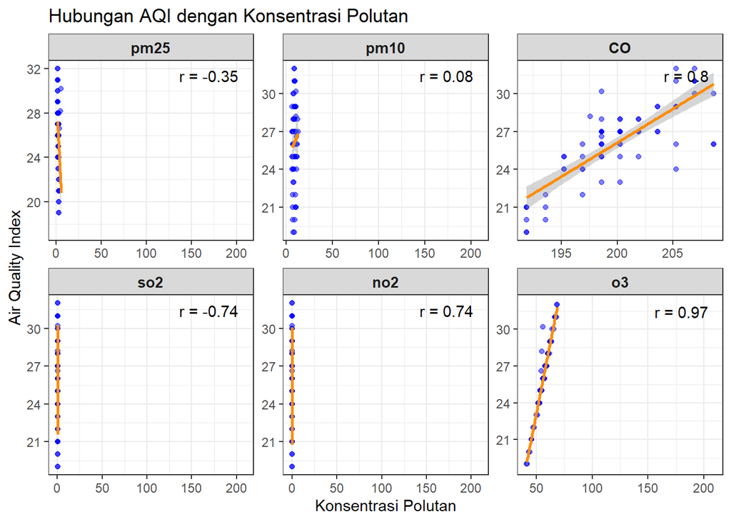

```r
# Plot hubungan AQI dengan tiap polutan
ggplot(air_long, aes(Konsentrasi, AQI)) +
  geom_point(color = "blue", alpha = 0.5) +           # titik data
  geom_smooth(method = "lm", color = "darkorange") + # garis trend
  facet_wrap(~Polutan, scales = "free") +
  geom_text(data = cor_vals,
            aes(x = max(air_long$Konsentrasi, na.rm = TRUE),
                y = max(air_long$AQI, na.rm = TRUE),
                label = label_r),
            inherit.aes = FALSE, hjust = 1.1, vjust = 1.1) +
  labs(title = "Hubungan AQI dengan Konsentrasi Polutan",
       x = "Konsentrasi Polutan", y = "Air Quality Index") +
  theme_bw() +
  theme(strip.text = element_text(size = 10, face = "bold"))
```

Variabel X terbaik untuk dipilih adalah O3, karena memiliki korelasi paling tinggi (r = 0.97) dengan AQI. # Eksplorasi Data

```r
aqi_data_ts <- ts(aqi_data$AQI)
summary(aqi_data_ts)
```

```
##    Min. 1st Qu.  Median    Mean 3rd Qu.    Max.
##   19.00   25.00   27.00   26.18   28.00   32.00
```

```r
# Ubah ke time series
aqi.ts <- ts(aqi_data$AQI)
o3.ts  <- ts(aqi_data$o3)

# Statistik deskriptif
summary(aqi.ts)
```

```
##    Min. 1st Qu.  Median    Mean 3rd Qu.    Max.
##   19.00   25.00   27.00   26.18   28.00   32.00
```

```r
summary(o3.ts)
```

```
##    Min. 1st Qu.  Median    Mean 3rd Qu.    Max.
##   41.48   53.64   57.22   56.57   60.08   68.66
```

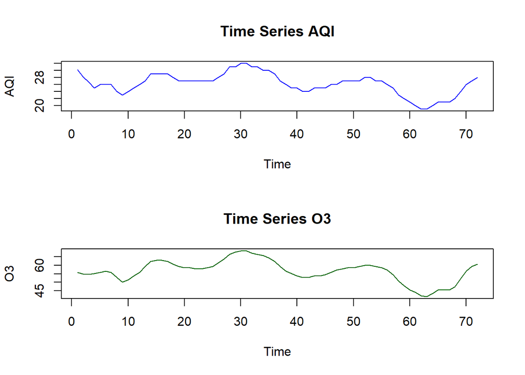

```r
# Plot time series AQI & O3
par(mfrow=c(2,1))
ts.plot(aqi.ts, main="Time Series AQI", ylab="AQI", col="blue")
ts.plot(o3.ts, main="Time Series O3", ylab="O3", col="darkgreen")
```

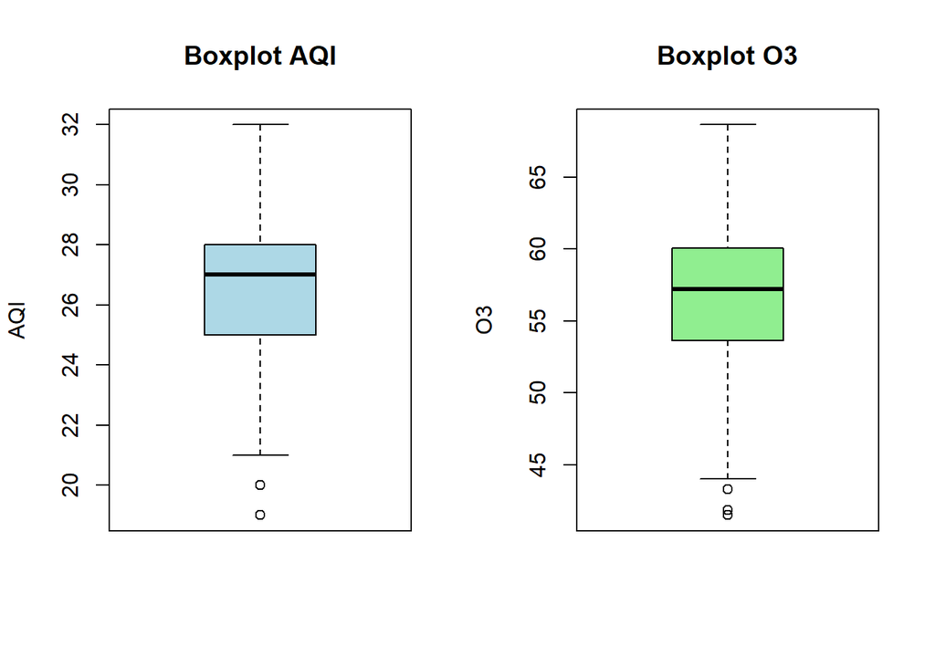

```r
par(mfrow=c(1,1))

# Boxplot AQI dan O3
par(mfrow=c(1,2))  # bagi layar jadi 1 baris 2 kolom
boxplot(aqi_data$AQI, main="Boxplot AQI", col="lightblue", ylab="AQI")
boxplot(aqi_data$o3, main="Boxplot O3", col="lightgreen", ylab="O3")
```

```r
par(mfrow=c(1,1))  # reset layout
```

Hasil boxplot menunjukkan bahwa kualitas udara di New Delhi (AQI) umumnya stabil pada kisaran sedang dengan sedikit variasi, meskipun ada beberapa hari dengan kondisi udara yang lebih baik dari biasanya (outlier). Sementara itu, kadar O3 cenderung lebih berfluktuasi dengan sebaran nilai yang lebih lebar, menandakan bahwa konsentrasi ozon di udara lebih mudah berubah dari waktu ke waktu. # Pengecekan Asumsi

```r
# Uji Durbin-Watson
lm_model <- lm(AQI ~ o3, data=aqi_data)
dwtest(lm_model)
```

```
##
##  Durbin-Watson test
##
## data:  lm_model
## DW = 0.54636, p-value = 3.207e-14
## alternative hypothesis: true autocorrelation is greater than 0
```

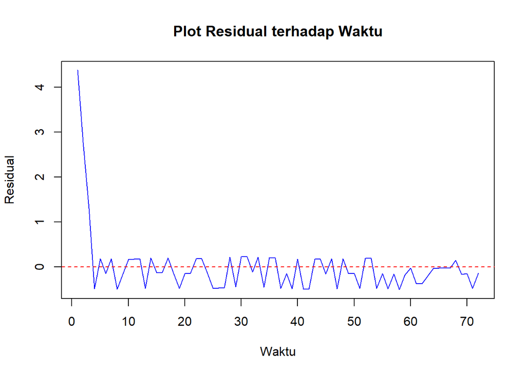

```r
# Ambil residual dari model
resid_lm <- residuals(lm_model)

# Plot residual terhadap waktu
plot(resid_lm, type = "l",
     main = "Plot Residual terhadap Waktu",
     xlab = "Waktu", ylab = "Residual",
     col = "blue")

abline(h = 0, col = "red", lty = 2)   # garis horizontal nol
```

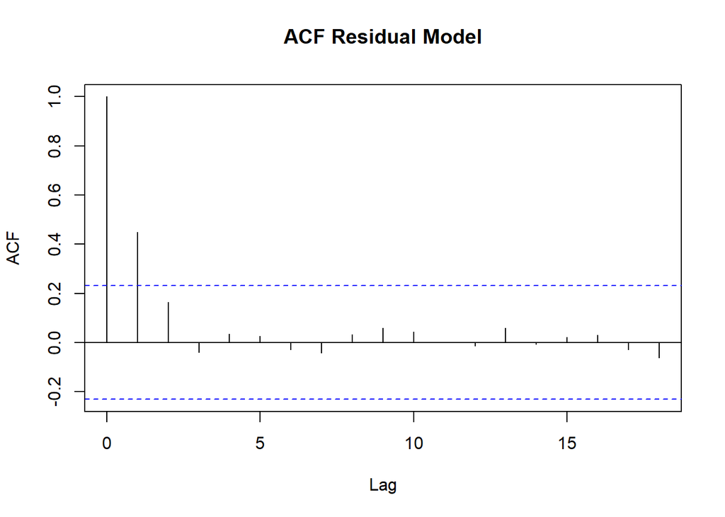

```r
# Plot ACF (Autocorrelation Function)
acf(resid_lm,
    main = "ACF Residual Model")
```

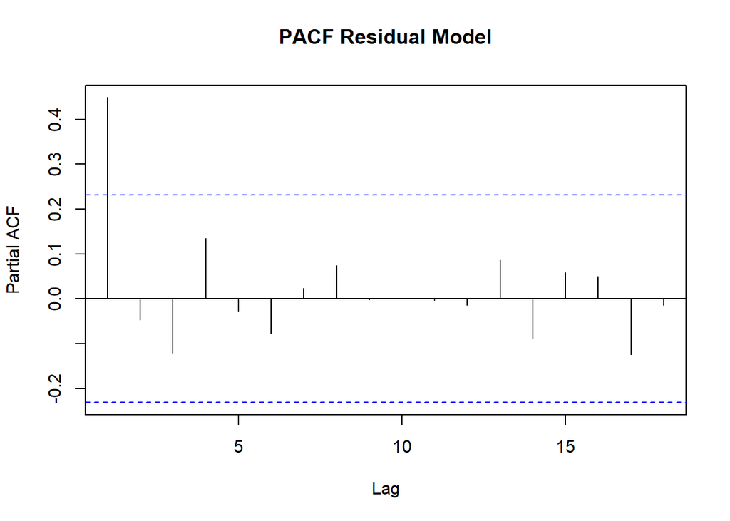

```r
# Plot PACF (Partial Autocorrelation Function)
pacf(resid_lm,
     main = "PACF Residual Model")
```

Berdasarkan grafik residual maupun hasil uji Durbin–Watson, model regresi linier yang digunakan mengalami masalah autokorelasi residual positif. Artinya, kesalahan pada periode tertentu cenderung berkorelasi dengan kesalahan pada periode berikutnya. Hal ini membuat asumsi klasik regresi tidak terpenuhi sehingga estimasi OLS bisa menjadi tidak efisien. # Splitting Data

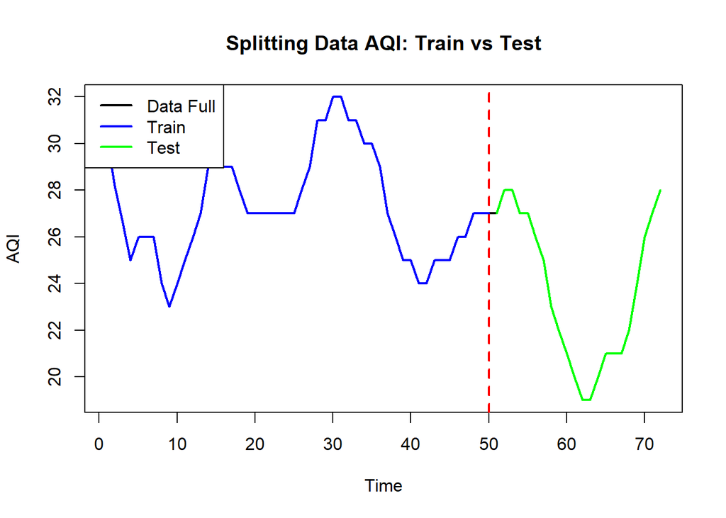

```r
n <- length(aqi.ts)
train_size <- round(0.7 * n)

aqi_train <- window(aqi.ts, end = c(train_size))
aqi_test  <- window(aqi.ts, start = c(train_size+1))

o3_train <- window(o3.ts, end = c(train_size))
o3_test  <- window(o3.ts, start = c(train_size+1))

# Splitting Data (70% train - 30% test)
n <- length(aqi.ts)
train_size <- round(0.7 * n)

aqi_train <- window(aqi.ts, end = c(train_size))
aqi_test  <- window(aqi.ts, start = c(train_size+1))

o3_train <- window(o3.ts, end = c(train_size))
o3_test  <- window(o3.ts, start = c(train_size+1))

# Plot Train vs Test
plot(aqi.ts, type="l", col="black", lwd=2,
     main="Splitting Data AQI: Train vs Test",
     ylab="AQI", xlab="Time")
abline(v = train_size, col="red", lty=2, lwd=2) # garis pemisah
lines(aqi_train, col="blue", lwd=2)
lines(aqi_test, col="green", lwd=2)
legend("topleft", legend=c("Data Full", "Train", "Test"),
       col=c("black", "blue", "green"), lty=1, lwd=2)
```